# question2

In Exercise 1.1 you performed an Exploratory Data Analysis on some of the sample data sets. Now continue with a further analysis of these data sets selected by studying their fingerprints both in the time and the frequency domain!

```r
data = get(load('../datasets/airline.RData'))
ts.airline <- ts(data$passenger,frequency=12, start=1949)
```

# a.

Obtain ‘the fingerprint’ of the (original) time series in the time domain by calculating the sample autocorrelation and partial autocorrelation function and comment on the results!

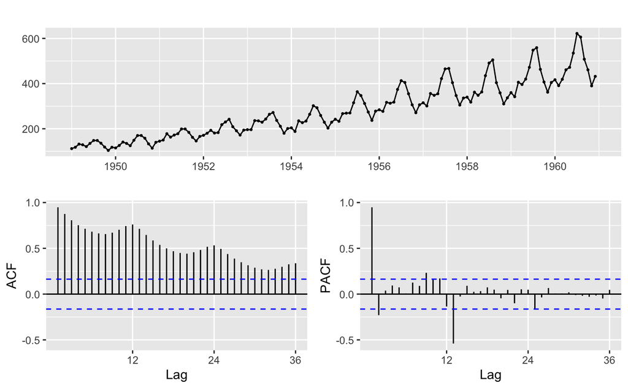

```r
# Autocorrelation:
### Measure for the overall correlation between {xt-k} and {xt} Both through the direct and the indirect pathway
# Partial autocorrelation
### Measure for the overall correlation between {xt-k} and {xt} Both through the direct and the indirect pathway
ggtsdisplay(ts.airline)
```

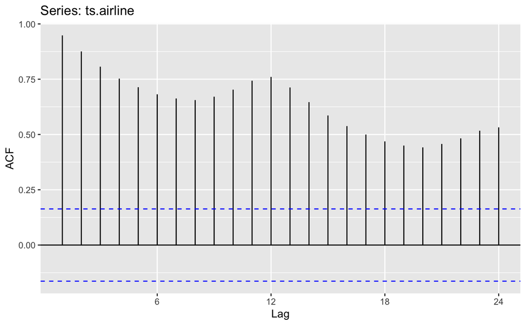

```r
ggAcf(ts.airline)
```

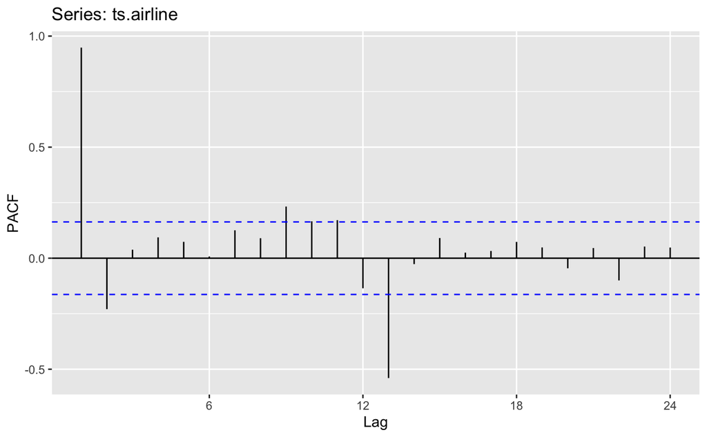

```r
ggPacf(ts.airline)
```

# b.

Apply finite and/or seasonal differencing to the original data to correct for trend and/or seasonality. Obtain ‘the fingerprint’ of the transformed time series in the time domain by calculating the sample autocorrelation and partial autocorrelation function and comment on the results!

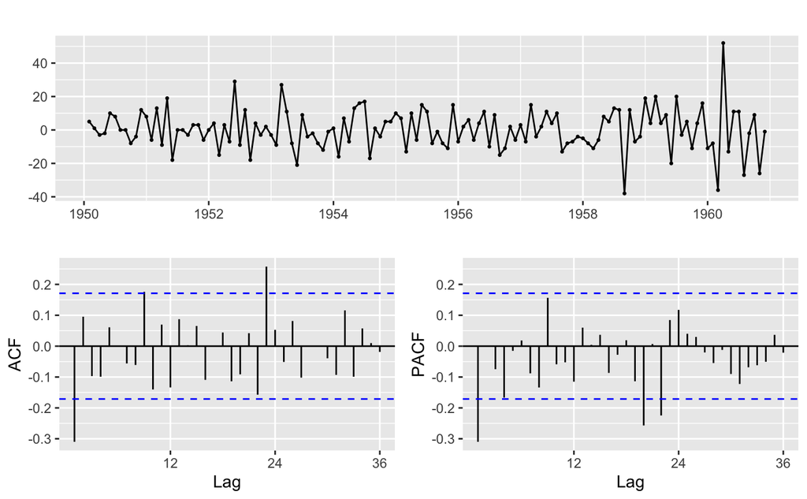

```r
# nearly gets rid of it
# differencing 1 for both is best
t1.diff <- diff(ts.airline, differences = 1)
t2.diff <- diff(ts.airline, differences = 2)
t1.s.diff <- diff(t1.diff, differences = 1, lag= 12)
t2.s.diff <- diff(t2.diff, differences = 1, lag= 12)
ggtsdisplay(t1.s.diff)
```

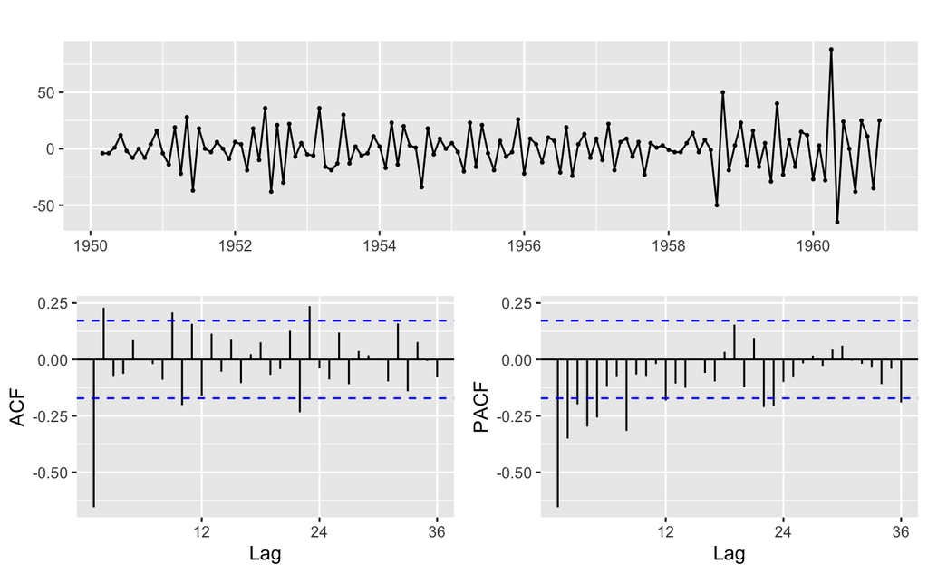

```r
ggtsdisplay(t2.s.diff)
```

# c.

Obtain ‘the fingerprint’ of both the original and the transformed time series in the frequency domain by calculating the (smoothed) spectrum, using the “spectrum” program. Comment on the results and try to identify frequency components that are present in the results!

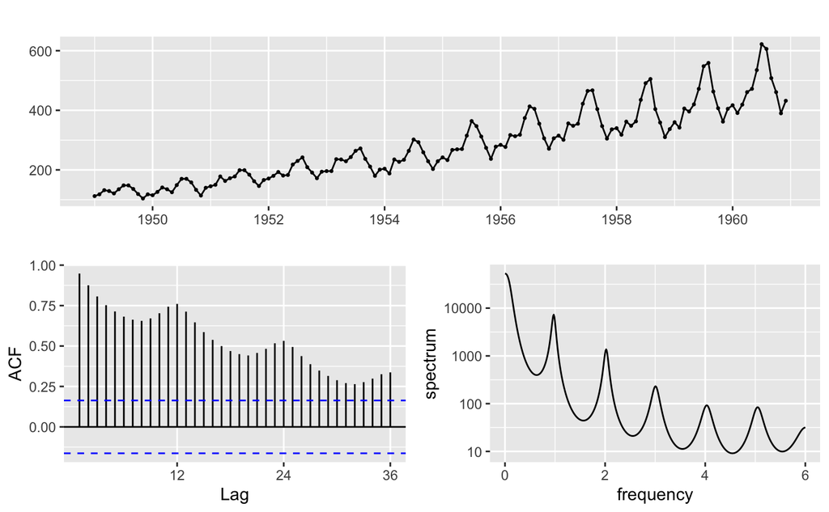

```r
ggtsdisplay(ts.airline, plot.type = 'spectrum')
```

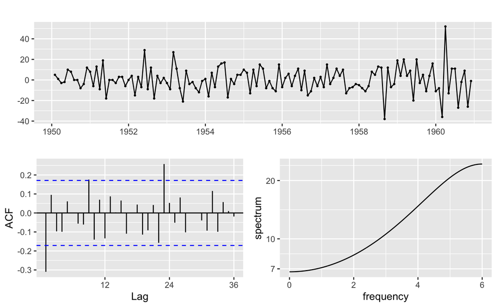

```r
ggtsdisplay(t1.s.diff, plot.type = 'spectrum')
```